# HW03

Jiawei Hao, hjiawei

Due 2021-09-28 at midnight

## Problem 1 (7 pts)

In the previous homework, we tested a hypothesis that stated that the distribution of the lenght of Perch was uniform within the interval $[0, \theta]$.. Plotting out the fish data, we see this assumption may not seem plausible:

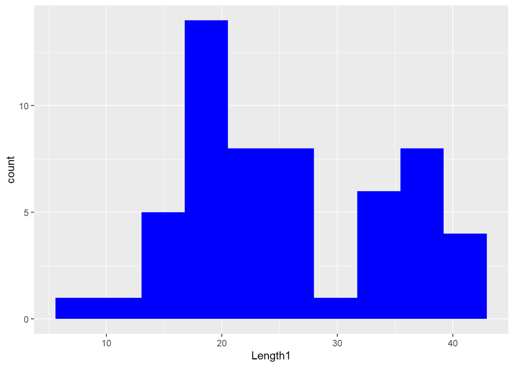

```r
ggplot(filter(fish, Species == 7), aes(x = Length1)) + geom_histogram(fill = "blue", bins = 10)
```

A slightly more flexible model is given by a **truncated Normal distribution**:

$$f(x) = I(x \in [0, \theta]) \frac{c(\mu, \sigma^2, \theta)}{\sqrt{2\pi \sigma^2}}\exp\left\{ -\frac{(x - \mu)^2}{2\sigma^2} \right\}$$
where $I(x \in [0, \theta])$ is the indicator function for the event that $x$ is in the region $[0, \theta]$ and $c$ is a function of the parameters that ensures that $f$ is a valid distribution.

We’ll fix $\theta = 50$. Here are some example truncated normal distributions:

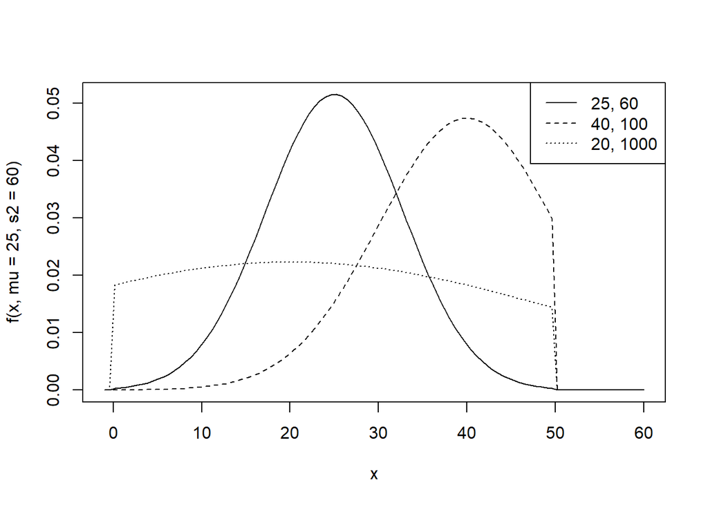

```r
f <- function(x, mu, s2) {
  const <- 1/(pnorm(50, mean = mu, sd = sqrt(s2)) -
                pnorm(0, mean = mu, sd = sqrt(s2)))
  ifelse(0 <= x & x <= 50,
         const * dnorm(x, mean = mu, sd = sqrt(s2)),
         0
  )
}
curve(f(x, mu = 25, s2 = 60), from = -1, to  = 60)
curve(f(x, mu = 40, s2 = 100), add = TRUE, lty = 2)
curve(f(x, mu = 20, s2 = 1000), add = TRUE, lty = 3)
legend(x = "topright", legend = c("25, 60", "40, 100", "20, 1000"), lty = 1:3)
```

### Part (a) (1 pt)

Prove that the following $c$ makes $f(x)$ a valid probability distribution:
$$c(\mu, \sigma^2, \theta) = \frac{1}{\Phi(\theta; \mu, \sigma^2) - \Phi(0; \mu, \sigma^2)}$$
where $\Phi(t; \mu, \sigma^2)$ is the culumative distribution function for a Normal random variable with mean $\mu$ and variance $\sigma^2$. [

$$\begin{align}
F(x)&=\int_{-\infty}^{\infty}f(x)dx \\
&=\int_{-\infty}^{\infty}I(x \in [0, \theta]) \frac{c(\mu, \sigma^2, \theta)}{\sqrt{2\pi \sigma^2}}\exp\left\{ -\frac{(x - \mu)^2}{2\sigma^2} \right\}dx \\
&=c\int_{0}^{\theta}\frac{(\mu, \sigma^2, \theta)}{\sqrt{2\pi \sigma^2}}\exp\left\{ -\frac{(x - \mu)^2}{2\sigma^2} \right\}dx \\
&=c \\
&=1
\end{align}$$
]

Thus we have
$$\Phi(\theta; \mu, \sigma^2) - \Phi(0; \mu, \sigma^2)=1$$
Which makes sense since our x takes value between $[0,\theta]$. This shows the area under the curve is 1, which is a property of probability density function.

### Part (b) (1 pt)

Use a Monte Carlo integration to estimate

$$P(X \ge 30) = E(I(X \ge 30))$$

for $\mu = 40$, $\sigma^2 = 100$, and $\theta = 50$. You can use `rnorm` to generate random variables $Y \sim N(\mu, \sigma^2$ and then just keep those that fall into the region $[0, 50]$. You should generate enough $Y$ so that you have at least 5000 $X$ after discarding $Y$ outside the $[0, 50]$ interval. Include a 99% confidence interval for this value.

```r
k = 10000
Y <- rnorm(k,40,10)
X <- Y[Y>=0&Y<=50]

greater_than_30_true_mean <- map_dbl(X,~ifelse(.x>=30,1,0))
true_mean=mean(greater_than_30_true_mean)
binom.test(sum(greater_than_30_true_mean),length(greater_than_30_true_mean),conf.level = 0.99)$conf.int
```

```
## [1] 0.7993481 0.8214881
## attr(,"conf.level")
## [1] 0.99
```

### Part (c) (2 pt)

The empirical cumulative distribution function is given by
$$\hat F(x) = \frac{1}{n} \sum_{i=1}^n I(X_i \le x)$$

Generate the sampling distribution of $\hat F(30)$ from sample of 56 units from the distribution in part (b): $(\mu = 40, \sigma^2 = 100, \theta = 50)$. Use 1000 replications of samples of size 56.

```r
f1<-function(v){
  v1 <- rnorm(v,40,10)
  v2 <- v1[0<=v1&v1<=50]
}
samples <- replicate(1000, map_dbl(f1(56),~ifelse(.x>=30,1,0)))
samples_means =c()
for (lst in samples){
  samples_means=append(samples_means,mean(lst))
}
var=var(samples_means)
bias=mean(samples_means)-true_mean
mse=mean((samples_means-true_mean)^2)
```

Using the estimate of $F(30)$ from part (b) as the true $P(X \ge 30)$, estimate the bias, variance, and mean squared error of the sample mean of 56 observations when estimating. Include a 99% confidence interval for each. Would you say $\hat F(30)$ is unbiased? Why or why not?

### Part (d) (2 pt)

A naive approach to working with truncated Normal distributions is to use $\bar X$ to estimate $\mu$ and $S^2$ (the sample variance) to estimate $\sigma^2$. Neither of these is a particularly good estimator, so let’s see how poorly they perform.

Repeat part (c) by estimating $P(X \ge 30)$ using the CDF of the Normal distribution, using $\bar X$ and $S^2$ as parameters. Compute the bias, variance, and mean squared error for this estimator.

### Part (e) (1 pt)

Estimate the probability of a perch having length greater than 30 using one of the two methods from (c) or (d) using the sample of perch contained in the `fish` table included with this homework.

## Problem 2 (3 pts)

Suppose we are sampling independent observations $X_i$ from a distribution for which we assume
$$\text{E}(X) < \infty, \quad \text{E}(X^2) < \infty$$
so that the Central Limit Theorem will apply. Writing $\mu = \text{E}(X)$ and $\sigma^2 = \text{E}((X - \mu)^2)$, the CLT states that for large samples the following approximation holds:
$$\bar X \sim N(\mu, \sigma^2/n)$$
A corrollary of the CLT is that we have (approximately),
$$\frac{\bar X - \mu}{s/\sqrt{n}} \sim t(n - 1)$$
where $s$ is the square root of the sample variance and $t(d)$ is the $t$-distribution with $d$ degrees of freedom. As we saw in class, this gives rise to $(1 - \alpha) \times 100\%$ confidence intervals defined by the set of (two-sided) hypothesis tests that would not be rejected at the $\alpha$ level:
$$\bar X \pm t_{\alpha/2}(n - 1) s/\sqrt{n}$$

If $\bar X$ were really Normal, this relationship would hold exactly (which would only occur when the $X_i$ are themselves Normal), but the rest of the time it is simply an approximation. Let’s test how well it works in some specific cases.

For each problem, generate 10,000 samples (each of size $n$, given below) and compute a 95% confidence interval. Estimate the confidence coefficient (i.e., $P(\mu \in \bar X \pm t_{0.975}(19) s/\sqrt{20})$) and provide a 99% CI for the confidence coefficient itself (use `binom.test`).

### Part (a) (1 pt)

The Laplace distribution (also known as the “double exponential distribution”) is given by:

$$f(x) = \frac{1}{2} \exp\left\{ -\left| x - \mu \right| \right\}$$
and can be generated using the following function:

```r
rlaplace <- function(n, mean) {
  s <- 2 * rbinom(n, size = 1, p = 0.5) - 1
  m <- rexp(n)
  s * m + mean
}
```

Estimate the coverage rate for a 95% two-sided confidence interval (use `t.test`) from samples drawn from:

$$n = 20, X_i \sim \text{Laplace}(1/2), \text{E}(X) = 1/2$$

### Part (b) (1 pt)

Compare two different sample sizes (see `rexp` to generate your samples):

$$n = 20, X_i \sim \text{Exp}(2), \text{E}(X) = 1/2$$

$$n = 500, X_i \sim \text{Exp}(2), \text{E}(X) = 1/2$$

What do you notice?

### Part (c) (1 pt)

Discuss the following “rule of thumb”: For any sample size greater than 30, we are safe to approximate the distribution of the sample mean as Normally distributed. Do you agree with this rule of thumb? Why or why not?